# Risk Factor Analysis

## Outcome Variable

**Outcome Variable:** haz

## Predictor Variables

**Intervention Variable:** safeh20

**Adjustment Set:**

- arm
- sex
- W_mage
- meducyrs
- feducyrs
- hhwealth_quart
- hfoodsec
- W_mhtcm
- W_mwtkg
- W_mbmi
- W_nrooms
- W_nchldlt5
- W_parity
- impfloor
- impsan
- delta_W_mage
- delta_meducyrs
- delta_feducyrs
- delta_hhwealth_quart
- delta_hfoodsec
- delta_W_mhtcm
- delta_W_mwtkg
- delta_W_mbmi
- delta_W_nrooms
- delta_W_nchldlt5
- delta_W_parity
- delta_impfloor
- delta_impsan

## Stratifying Variables

The analysis was stratified on these variable(s):

- agecat
- studyid
- country

## Data Summary

| agecat | studyid | country | safeh20 | n_cell | n | outcome_variable |
| --- | --- | --- | --- | --- | --- | --- |
| Birth | JiVitA-3 | BANGLADESH | 1 | 22392 | 22432 | haz |
| Birth | JiVitA-3 | BANGLADESH | 0 | 40 | 22432 | haz |
| Birth | JiVitA-4 | BANGLADESH | 1 | 2820 | 2820 | haz |
| Birth | JiVitA-4 | BANGLADESH | 0 | 0 | 2820 | haz |
| Birth | MAL-ED | BANGLADESH | 1 | 0 | 213 | haz |
| Birth | MAL-ED | BANGLADESH | 0 | 213 | 213 | haz |
| Birth | MAL-ED | BRAZIL | 1 | 0 | 41 | haz |
| Birth | MAL-ED | BRAZIL | 0 | 41 | 41 | haz |
| Birth | MAL-ED | INDIA | 1 | 0 | 41 | haz |
| Birth | MAL-ED | INDIA | 0 | 41 | 41 | haz |
| Birth | MAL-ED | NEPAL | 1 | 1 | 26 | haz |
| Birth | MAL-ED | NEPAL | 0 | 25 | 26 | haz |
| Birth | MAL-ED | PERU | 1 | 9 | 207 | haz |
| Birth | MAL-ED | PERU | 0 | 198 | 207 | haz |
| Birth | MAL-ED | SOUTH AFRICA | 1 | 13 | 96 | haz |
| Birth | MAL-ED | SOUTH AFRICA | 0 | 83 | 96 | haz |
| Birth | MAL-ED | TANZANIA, UNITED REPUBLIC OF | 1 | 79 | 119 | haz |
| Birth | MAL-ED | TANZANIA, UNITED REPUBLIC OF | 0 | 40 | 119 | haz |
| Birth | NIH-Birth | BANGLADESH | 1 | 606 | 608 | haz |
| Birth | NIH-Birth | BANGLADESH | 0 | 2 | 608 | haz |
| Birth | NIH-Crypto | BANGLADESH | 1 | 732 | 732 | haz |
| Birth | NIH-Crypto | BANGLADESH | 0 | 0 | 732 | haz |
| Birth | PROVIDE | BANGLADESH | 1 | 45 | 45 | haz |
| Birth | PROVIDE | BANGLADESH | 0 | 0 | 45 | haz |
| 6 months | CONTENT | PERU | 1 | 54 | 57 | haz |
| 6 months | CONTENT | PERU | 0 | 3 | 57 | haz |
| 6 months | JiVitA-3 | BANGLADESH | 1 | 16783 | 16803 | haz |
| 6 months | JiVitA-3 | BANGLADESH | 0 | 20 | 16803 | haz |
| 6 months | JiVitA-4 | BANGLADESH | 1 | 4824 | 4825 | haz |
| 6 months | JiVitA-4 | BANGLADESH | 0 | 1 | 4825 | haz |

[output cut: 52 more lines]

The following strata were considered:

- agecat: 24 months, studyid: CONTENT, country: PERU
- agecat: 24 months, studyid: JiVitA-3, country: BANGLADESH
- agecat: 24 months, studyid: JiVitA-4, country: BANGLADESH
- agecat: 24 months, studyid: LCNI-5, country: MALAWI
- agecat: 24 months, studyid: MAL-ED, country: BANGLADESH
- agecat: 24 months, studyid: MAL-ED, country: BRAZIL
- agecat: 24 months, studyid: MAL-ED, country: INDIA
- agecat: 24 months, studyid: MAL-ED, country: NEPAL
- agecat: 24 months, studyid: MAL-ED, country: PERU
- agecat: 24 months, studyid: MAL-ED, country: SOUTH AFRICA
- agecat: 24 months, studyid: MAL-ED, country: TANZANIA, UNITED REPUBLIC OF
- agecat: 24 months, studyid: NIH-Birth, country: BANGLADESH
- agecat: 24 months, studyid: NIH-Crypto, country: BANGLADESH
- agecat: 24 months, studyid: PROVIDE, country: BANGLADESH
- agecat: 6 months, studyid: CONTENT, country: PERU
- agecat: 6 months, studyid: JiVitA-3, country: BANGLADESH
- agecat: 6 months, studyid: JiVitA-4, country: BANGLADESH
- agecat: 6 months, studyid: LCNI-5, country: MALAWI
- agecat: 6 months, studyid: MAL-ED, country: BANGLADESH
- agecat: 6 months, studyid: MAL-ED, country: BRAZIL
- agecat: 6 months, studyid: MAL-ED, country: INDIA
- agecat: 6 months, studyid: MAL-ED, country: NEPAL
- agecat: 6 months, studyid: MAL-ED, country: PERU
- agecat: 6 months, studyid: MAL-ED, country: SOUTH AFRICA
- agecat: 6 months, studyid: MAL-ED, country: TANZANIA, UNITED REPUBLIC OF
- agecat: 6 months, studyid: NIH-Birth, country: BANGLADESH
- agecat: 6 months, studyid: NIH-Crypto, country: BANGLADESH
- agecat: 6 months, studyid: PROVIDE, country: BANGLADESH
- agecat: 6 months, studyid: SAS-FoodSuppl, country: INDIA
- agecat: Birth, studyid: JiVitA-3, country: BANGLADESH
- agecat: Birth, studyid: JiVitA-4, country: BANGLADESH
- agecat: Birth, studyid: MAL-ED, country: BANGLADESH
- agecat: Birth, studyid: MAL-ED, country: BRAZIL
- agecat: Birth, studyid: MAL-ED, country: INDIA
- agecat: Birth, studyid: MAL-ED, country: NEPAL
- agecat: Birth, studyid: MAL-ED, country: PERU
- agecat: Birth, studyid: MAL-ED, country: SOUTH AFRICA
- agecat: Birth, studyid: MAL-ED, country: TANZANIA, UNITED REPUBLIC OF
- agecat: Birth, studyid: NIH-Birth, country: BANGLADESH
- agecat: Birth, studyid: NIH-Crypto, country: BANGLADESH
- agecat: Birth, studyid: PROVIDE, country: BANGLADESH

### Dropped Strata

- agecat: Birth, studyid: JiVitA-4, country: BANGLADESH
- agecat: Birth, studyid: MAL-ED, country: BANGLADESH
- agecat: Birth, studyid: MAL-ED, country: BRAZIL
- agecat: Birth, studyid: MAL-ED, country: INDIA
- agecat: Birth, studyid: MAL-ED, country: NEPAL
- agecat: Birth, studyid: NIH-Birth, country: BANGLADESH
- agecat: Birth, studyid: NIH-Crypto, country: BANGLADESH
- agecat: Birth, studyid: PROVIDE, country: BANGLADESH
- agecat: 6 months, studyid: CONTENT, country: PERU
- agecat: 6 months, studyid: JiVitA-4, country: BANGLADESH
- agecat: 6 months, studyid: MAL-ED, country: BANGLADESH
- agecat: 6 months, studyid: MAL-ED, country: BRAZIL
- agecat: 6 months, studyid: MAL-ED, country: INDIA
- agecat: 6 months, studyid: MAL-ED, country: NEPAL
- agecat: 6 months, studyid: NIH-Birth, country: BANGLADESH
- agecat: 6 months, studyid: NIH-Crypto, country: BANGLADESH
- agecat: 6 months, studyid: PROVIDE, country: BANGLADESH
- agecat: 6 months, studyid: SAS-FoodSuppl, country: INDIA
- agecat: 24 months, studyid: CONTENT, country: PERU
- agecat: 24 months, studyid: JiVitA-4, country: BANGLADESH
- agecat: 24 months, studyid: MAL-ED, country: BANGLADESH
- agecat: 24 months, studyid: MAL-ED, country: BRAZIL
- agecat: 24 months, studyid: MAL-ED, country: INDIA
- agecat: 24 months, studyid: MAL-ED, country: NEPAL
- agecat: 24 months, studyid: NIH-Birth, country: BANGLADESH
- agecat: 24 months, studyid: NIH-Crypto, country: BANGLADESH
- agecat: 24 months, studyid: PROVIDE, country: BANGLADESH

## Methods Detail

We’re interested in the causal parameters $E[Y_a]$ for all values of $a \in \mathcal{A}$. These parameters represent the mean outcome if, possibly contrary to fact, we intervened to set all units to have $A=a$. Under the randomization and positivity assumptions, these are identified by the statistical parameters $\psi_a=E_W[E_{Y|A,W}(Y|A=a,W)]$. In addition, we’re interested in the mean of $Y$, $E[Y]$ under no intervention (the observed mean). We will estimate these parameters by using SuperLearner to fit the relevant likelihood factors – $E_{Y|A,W}(Y|A=a,W)$ and $p(A=a|W)$, and then updating our likelihood fit using a joint TMLE.

For unadjusted analyses ($W=\{\}$), initial likelihoods were estimated using Lrnr_glm to estimate the simple $E(Y|A)$ and Lrnr_mean to estimate $p(A)$. For adjusted analyses, a small library containing Lrnr_glmnet, Lrnr_xgboost, and Lrnr_mean was used.

Having estimated these parameters, we will then use the delta method to estimate relative risks and attributable risks relative to a prespecified baseline level of $A$.

# Results Detail

## Results Plots

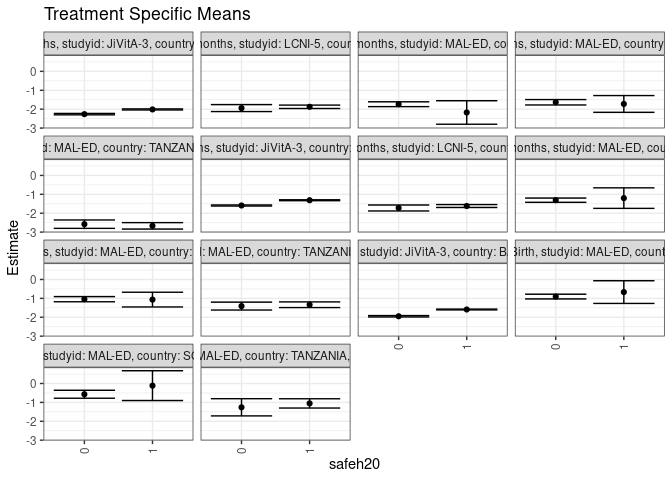

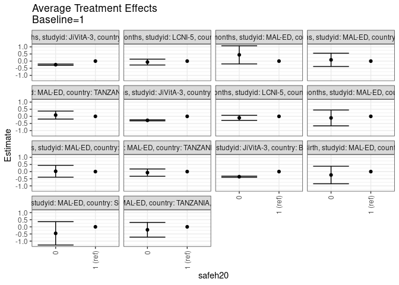

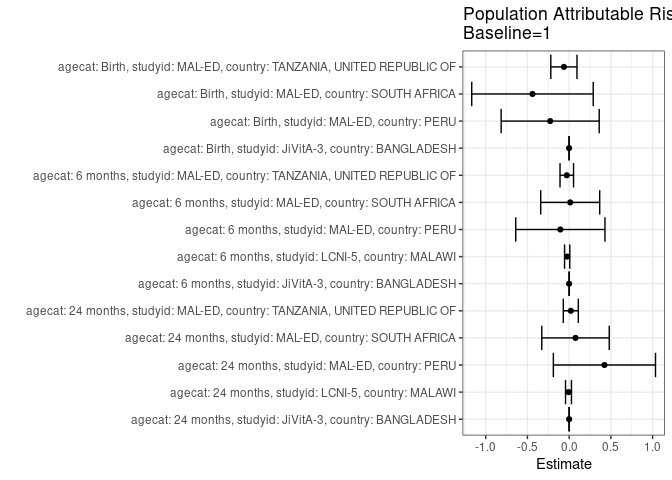

## Results Table

### Parameter: TSM

| agecat | studyid | country | intervention_level | baseline_level | estimate | ci_lower | ci_upper |
| --- | --- | --- | --- | --- | --- | --- | --- |
| Birth | JiVitA-3 | BANGLADESH | 1 | NA | -1.5889965 | -1.6086623 | -1.5693306 |
| Birth | JiVitA-3 | BANGLADESH | 0 | NA | -1.9472966 | -1.9831472 | -1.9114460 |
| Birth | MAL-ED | PERU | 1 | NA | -0.6677778 | -1.2689426 | -0.0666129 |
| Birth | MAL-ED | PERU | 0 | NA | -0.9054040 | -1.0308665 | -0.7799416 |
| Birth | MAL-ED | SOUTH AFRICA | 1 | NA | -0.1130146 | -0.9016098 | 0.6755805 |
| Birth | MAL-ED | SOUTH AFRICA | 0 | NA | -0.5688438 | -0.7797085 | -0.3579791 |
| Birth | MAL-ED | TANZANIA, UNITED REPUBLIC OF | 1 | NA | -1.0528125 | -1.2971296 | -0.8084954 |
| Birth | MAL-ED | TANZANIA, UNITED REPUBLIC OF | 0 | NA | -1.2593260 | -1.7134727 | -0.8051792 |
| 6 months | JiVitA-3 | BANGLADESH | 1 | NA | -1.3128530 | -1.3365108 | -1.2891952 |
| 6 months | JiVitA-3 | BANGLADESH | 0 | NA | -1.5919462 | -1.6211703 | -1.5627221 |
| 6 months | LCNI-5 | MALAWI | 1 | NA | -1.6190000 | -1.6960442 | -1.5419558 |
| 6 months | LCNI-5 | MALAWI | 0 | NA | -1.7233006 | -1.8811486 | -1.5654526 |
| 6 months | MAL-ED | PERU | 1 | NA | -1.2009819 | -1.7440560 | -0.6579077 |
| 6 months | MAL-ED | PERU | 0 | NA | -1.3115277 | -1.4244235 | -1.1986320 |
| 6 months | MAL-ED | SOUTH AFRICA | 1 | NA | -1.0660539 | -1.4561797 | -0.6759282 |
| 6 months | MAL-ED | SOUTH AFRICA | 0 | NA | -1.0440017 | -1.1807545 | -0.9072489 |
| 6 months | MAL-ED | TANZANIA, UNITED REPUBLIC OF | 1 | NA | -1.3375743 | -1.4867351 | -1.1884134 |
| 6 months | MAL-ED | TANZANIA, UNITED REPUBLIC OF | 0 | NA | -1.4092954 | -1.6187644 | -1.1998264 |
| 24 months | JiVitA-3 | BANGLADESH | 1 | NA | -2.0132737 | -2.0416087 | -1.9849387 |
| 24 months | JiVitA-3 | BANGLADESH | 0 | NA | -2.2630937 | -2.2991470 | -2.2270404 |
| 24 months | LCNI-5 | MALAWI | 1 | NA | -1.8743142 | -1.9649839 | -1.7836445 |
| 24 months | LCNI-5 | MALAWI | 0 | NA | -1.9424445 | -2.1275165 | -1.7573724 |
| 24 months | MAL-ED | PERU | 1 | NA | -2.1757143 | -2.7976265 | -1.5538020 |
| 24 months | MAL-ED | PERU | 0 | NA | -1.7370699 | -1.8647759 | -1.6093639 |
| 24 months | MAL-ED | SOUTH AFRICA | 1 | NA | -1.7232096 | -2.1675743 | -1.2788448 |
| 24 months | MAL-ED | SOUTH AFRICA | 0 | NA | -1.6342882 | -1.7765105 | -1.4920658 |
| 24 months | MAL-ED | TANZANIA, UNITED REPUBLIC OF | 1 | NA | -2.6687426 | -2.8390059 | -2.4984794 |
| 24 months | MAL-ED | TANZANIA, UNITED REPUBLIC OF | 0 | NA | -2.5792121 | -2.8019192 | -2.3565050 |

### Parameter: E(Y)

| agecat | studyid | country | intervention_level | baseline_level | estimate | ci_lower | ci_upper |
| --- | --- | --- | --- | --- | --- | --- | --- |
| Birth | JiVitA-3 | BANGLADESH | NA | NA | -1.5896835 | -1.6089596 | -1.5704074 |
| Birth | MAL-ED | PERU | NA | NA | -0.8950725 | -1.0180716 | -0.7720734 |
| Birth | MAL-ED | SOUTH AFRICA | NA | NA | -0.5523958 | -0.7550074 | -0.3497843 |
| Birth | MAL-ED | TANZANIA, UNITED REPUBLIC OF | NA | NA | -1.1158824 | -1.3283278 | -0.9034369 |
| 6 months | JiVitA-3 | BANGLADESH | NA | NA | -1.3132090 | -1.3363486 | -1.2900693 |
| 6 months | LCNI-5 | MALAWI | NA | NA | -1.6426961 | -1.7120603 | -1.5733318 |
| 6 months | MAL-ED | PERU | NA | NA | -1.3065026 | -1.4164323 | -1.1965728 |
| 6 months | MAL-ED | SOUTH AFRICA | NA | NA | -1.0533804 | -1.1834360 | -0.9233247 |
| 6 months | MAL-ED | TANZANIA, UNITED REPUBLIC OF | NA | NA | -1.3658943 | -1.4882808 | -1.2435078 |
| 24 months | JiVitA-3 | BANGLADESH | NA | NA | -2.0135591 | -2.0412422 | -1.9858759 |
| 24 months | LCNI-5 | MALAWI | NA | NA | -1.8822648 | -1.9637218 | -1.8008078 |
| 24 months | MAL-ED | PERU | NA | NA | -1.7529793 | -1.8786399 | -1.6273186 |
| 24 months | MAL-ED | SOUTH AFRICA | NA | NA | -1.6471273 | -1.7822999 | -1.5119547 |
| 24 months | MAL-ED | TANZANIA, UNITED REPUBLIC OF | NA | NA | -2.6488498 | -2.7844961 | -2.5132034 |

### Parameter: ATE

| agecat | studyid | country | intervention_level | baseline_level | estimate | ci_lower | ci_upper |
| --- | --- | --- | --- | --- | --- | --- | --- |
| Birth | JiVitA-3 | BANGLADESH | 1 | 1 | 0.0000000 | 0.0000000 | 0.0000000 |
| Birth | JiVitA-3 | BANGLADESH | 0 | 1 | -0.3583001 | -0.3979408 | -0.3186594 |
| Birth | MAL-ED | PERU | 1 | 1 | 0.0000000 | 0.0000000 | 0.0000000 |
| Birth | MAL-ED | PERU | 0 | 1 | -0.2376263 | -0.8517435 | 0.3764910 |
| Birth | MAL-ED | SOUTH AFRICA | 1 | 1 | 0.0000000 | 0.0000000 | 0.0000000 |
| Birth | MAL-ED | SOUTH AFRICA | 0 | 1 | -0.4558292 | -1.2740722 | 0.3624139 |
| Birth | MAL-ED | TANZANIA, UNITED REPUBLIC OF | 1 | 1 | 0.0000000 | 0.0000000 | 0.0000000 |
| Birth | MAL-ED | TANZANIA, UNITED REPUBLIC OF | 0 | 1 | -0.2065135 | -0.7229274 | 0.3099005 |
| 6 months | JiVitA-3 | BANGLADESH | 1 | 1 | 0.0000000 | 0.0000000 | 0.0000000 |
| 6 months | JiVitA-3 | BANGLADESH | 0 | 1 | -0.2790932 | -0.3149762 | -0.2432102 |
| 6 months | LCNI-5 | MALAWI | 1 | 1 | 0.0000000 | 0.0000000 | 0.0000000 |
| 6 months | LCNI-5 | MALAWI | 0 | 1 | -0.1043006 | -0.2800381 | 0.0714369 |
| 6 months | MAL-ED | PERU | 1 | 1 | 0.0000000 | 0.0000000 | 0.0000000 |
| 6 months | MAL-ED | PERU | 0 | 1 | -0.1105459 | -0.6652678 | 0.4441760 |
| 6 months | MAL-ED | SOUTH AFRICA | 1 | 1 | 0.0000000 | 0.0000000 | 0.0000000 |
| 6 months | MAL-ED | SOUTH AFRICA | 0 | 1 | 0.0220522 | -0.3922837 | 0.4363881 |
| 6 months | MAL-ED | TANZANIA, UNITED REPUBLIC OF | 1 | 1 | 0.0000000 | 0.0000000 | 0.0000000 |
| 6 months | MAL-ED | TANZANIA, UNITED REPUBLIC OF | 0 | 1 | -0.0717211 | -0.3269062 | 0.1834639 |
| 24 months | JiVitA-3 | BANGLADESH | 1 | 1 | 0.0000000 | 0.0000000 | 0.0000000 |
| 24 months | JiVitA-3 | BANGLADESH | 0 | 1 | -0.2498200 | -0.2947621 | -0.2048778 |
| 24 months | LCNI-5 | MALAWI | 1 | 1 | 0.0000000 | 0.0000000 | 0.0000000 |
| 24 months | LCNI-5 | MALAWI | 0 | 1 | -0.0681303 | -0.2742561 | 0.1379956 |
| 24 months | MAL-ED | PERU | 1 | 1 | 0.0000000 | 0.0000000 | 0.0000000 |
| 24 months | MAL-ED | PERU | 0 | 1 | 0.4386444 | -0.1962443 | 1.0735331 |
| 24 months | MAL-ED | SOUTH AFRICA | 1 | 1 | 0.0000000 | 0.0000000 | 0.0000000 |
| 24 months | MAL-ED | SOUTH AFRICA | 0 | 1 | 0.0889214 | -0.3769606 | 0.5548034 |
| 24 months | MAL-ED | TANZANIA, UNITED REPUBLIC OF | 1 | 1 | 0.0000000 | 0.0000000 | 0.0000000 |
| 24 months | MAL-ED | TANZANIA, UNITED REPUBLIC OF | 0 | 1 | 0.0895305 | -0.1906812 | 0.3697423 |

### Parameter: PAR

| agecat | studyid | country | intervention_level | baseline_level | estimate | ci_lower | ci_upper |
| --- | --- | --- | --- | --- | --- | --- | --- |
| Birth | JiVitA-3 | BANGLADESH | 1 | NA | -0.0006870 | -0.0017090 | 0.0003350 |
| Birth | MAL-ED | PERU | 1 | NA | -0.2272947 | -0.8147485 | 0.3601591 |
| Birth | MAL-ED | SOUTH AFRICA | 1 | NA | -0.4393812 | -1.1674004 | 0.2886380 |
| Birth | MAL-ED | TANZANIA, UNITED REPUBLIC OF | 1 | NA | -0.0630698 | -0.2199047 | 0.0937650 |
| 6 months | JiVitA-3 | BANGLADESH | 1 | NA | -0.0003560 | -0.0012541 | 0.0005422 |
| 6 months | LCNI-5 | MALAWI | 1 | NA | -0.0236961 | -0.0548866 | 0.0074944 |
| 6 months | MAL-ED | PERU | 1 | NA | -0.1055207 | -0.6401032 | 0.4290618 |
| 6 months | MAL-ED | SOUTH AFRICA | 1 | NA | 0.0126735 | -0.3406347 | 0.3659818 |
| 6 months | MAL-ED | TANZANIA, UNITED REPUBLIC OF | 1 | NA | -0.0283200 | -0.1093064 | 0.0526664 |
| 24 months | JiVitA-3 | BANGLADESH | 1 | NA | -0.0002853 | -0.0014384 | 0.0008677 |
| 24 months | LCNI-5 | MALAWI | 1 | NA | -0.0079506 | -0.0434510 | 0.0275498 |
| 24 months | MAL-ED | PERU | 1 | NA | 0.4227350 | -0.1892366 | 1.0347066 |
| 24 months | MAL-ED | SOUTH AFRICA | 1 | NA | 0.0760823 | -0.3282690 | 0.4804335 |
| 24 months | MAL-ED | TANZANIA, UNITED REPUBLIC OF | 1 | NA | 0.0198929 | -0.0700019 | 0.1097876 |